# regression problem

Nadezda Carr

2/16/2020

# Introduction:

Data are from the website http://fueleconomy.gov This is a problem in modeling/prediction. The idea is this: Fuel efficiency from 2010 and 2011 passenger cars and light trucks is provied. Using data from 2010, find the best model to predict fuel effiency; fit the model using data from 2010, and evaluate model performance using 2011 data.

Questions:  
1. Is there evidence of an improvement in fuel efficiency from 2010 to 2011?  
2. What variables are most significant predictors of fuel efficienty?  
3. Suggest ways in which fuel efficienty could be improved in future years.

data set: fuel economy from US Gov’t website

```r
data(FuelEconomy)
library(lattice)
```

### Plot shown in the text:

load the data FE is fuel economy

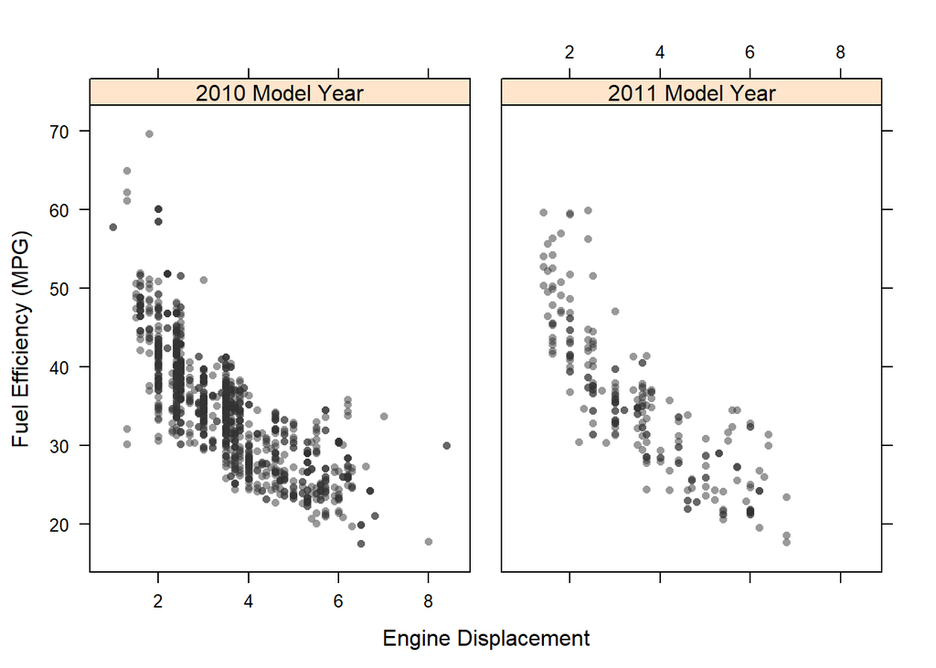

```r
cars2010 <- cars2010[order(cars2010$EngDispl),]
cars2011 <- cars2011[order(cars2011$EngDispl),]
cars2010a <- cars2010
cars2010a$Year <- "2010 Model Year"
cars2011a <- cars2011
cars2011a$Year <- "2011 Model Year"
plotData <- rbind(cars2010a, cars2011a)
plotTheme <- bookTheme(FALSE)
plotTheme$plot.symbol$col <- rgb(.2, .2, .2, .5)
plotTheme$plot.symbol$cex <- 0.7
trellis.par.set(plotTheme)

xyplot(FE ~ EngDispl|Year, plotData,
xlab = "Engine Displacement",
ylab = "Fuel Efficiency (MPG)",
between = list(x = 1.2))
```

## difference in mean fuel efficiency 2010 and 2011

$H_0$: no difference between FE in 2010 and 2011 $H_A$: there is a difference in FE for years 2010 and 2011

We’ll use the t-test for this inference:

```r
t.test(cars2010a$FE, cars2011a$FE)
```

```
##
##  Welch Two Sample t-test
##
## data:  cars2010a$FE and cars2011a$FE
## t = -0.038381, df = 319.38, p-value = 0.9694
## alternative hypothesis: true difference in means is not equal to 0
## 95 percent confidence interval:
##  -1.263399  1.215049
## sample estimates:
## mean of x mean of y
##  34.70649  34.73066
```

Question #1: No evidence of any improvement/difference in mean FE between 2010 and 2011

As an aside, is there a diference between average fuel efficiency in 2010 and 2012?

```r
t.test(cars2010a$FE, cars2012$FE)
```

```
##
##  Welch Two Sample t-test
##
## data:  cars2010a$FE and cars2012$FE
## t = -4.6618, df = 102.9, p-value = 9.433e-06
## alternative hypothesis: true difference in means is not equal to 0
## 95 percent confidence interval:
##  -7.113664 -2.867408
## sample estimates:
## mean of x mean of y
##  34.70649  39.69703
```

```r
par(mrow=2)
```

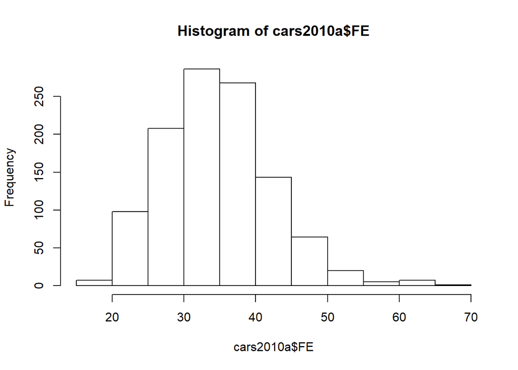

```r
hist(cars2010a$FE)
```

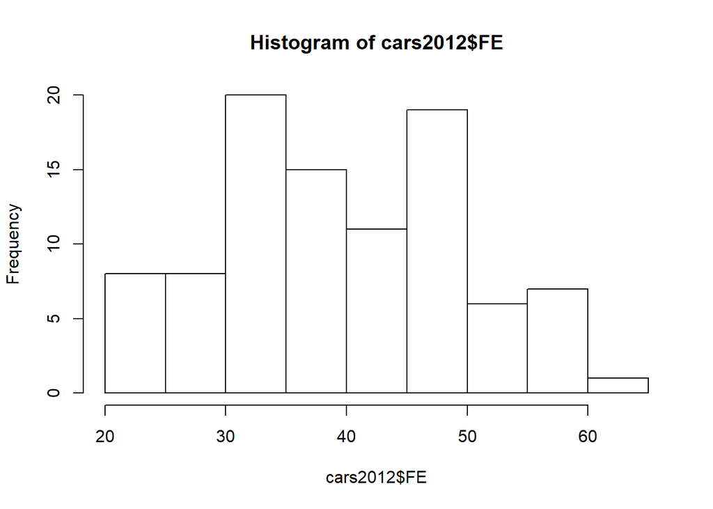

```r
hist(cars2012$FE)
```

### variables in the data set:

```r
names(cars2010a)
```

```
##  [1] "EngDispl"            "NumCyl"              "Transmission"
##  [4] "FE"                  "AirAspirationMethod" "NumGears"
##  [7] "TransLockup"         "TransCreeperGear"    "DriveDesc"
## [10] "IntakeValvePerCyl"   "ExhaustValvesPerCyl" "CarlineClassDesc"
## [13] "VarValveTiming"      "VarValveLift"        "Year"
```

```r
testTranny = filter(cars2010a, Transmission %in% c('AV', 'AM7'))
trannyModel = glm(FE ~ Transmission, data = testTranny)
summary(trannyModel)
```

```
##
## Call:
## glm(formula = FE ~ Transmission, data = testTranny)
##
## Deviance Residuals:
##    Min      1Q  Median      3Q     Max
## -9.926  -5.776  -1.729   2.781  29.415
##
## Coefficients:
##                Estimate Std. Error t value Pr(>|t|)
## (Intercept)      22.033      3.691   5.970 1.53e-07 ***
## TransmissionAV   18.192      3.855   4.719 1.54e-05 ***
## ---
## Signif. codes:  0 '***' 0.001 '**' 0.01 '*' 0.05 '.' 0.1 ' ' 1
##
## (Dispersion parameter for gaussian family taken to be 68.10654)
##
##     Null deviance: 5467.1  on 59  degrees of freedom
## Residual deviance: 3950.2  on 58  degrees of freedom
## AIC: 427.5
##
## Number of Fisher Scoring iterations: 2
```

```r
print(mean(testTranny$FE))
```

```
## [1] 38.70947
```

Try adding Exhaust Valves per Cylinder

```r
#levels(cars2010a$ExhaustValvesPerCyl)
levels(cars2010a$ExhaustValvesPerCyl)
```

[output not shown]

```r
trannyValveModel = glm(FE ~ Transmission + ExhaustValvesPerCyl, data = testTranny)
summary(trannyValveModel)
```

```
##
## Call:
## glm(formula = FE ~ Transmission + ExhaustValvesPerCyl, data = testTranny)
##
## Deviance Residuals:
##    Min      1Q  Median      3Q     Max
## -9.485  -5.854  -2.133   2.130  28.645
##
## Coefficients:
##                     Estimate Std. Error t value Pr(>|t|)
## (Intercept)           12.356      6.557   1.884   0.0646 .
## TransmissionAV        19.160      3.825   5.009 5.61e-06 ***
## ExhaustValvesPerCyl    4.839      2.732   1.771   0.0819 .
## ---
## Signif. codes:  0 '***' 0.001 '**' 0.01 '*' 0.05 '.' 0.1 ' ' 1
##
## (Dispersion parameter for gaussian family taken to be 65.68668)
##
##     Null deviance: 5467.1  on 59  degrees of freedom
## Residual deviance: 3744.1  on 57  degrees of freedom
## AIC: 426.29
##
## Number of Fisher Scoring iterations: 2
```

Try adding air aspiration method to see what it does

```r
#levels(cars2010a$AirAspirationMethod)
levels(cars2010a$AirAspirationMethod)
```

```
## [1] "NaturallyAspirated" "Supercharged"       "Turbocharged"
```

```r
trannyAirModel = glm(FE ~ Transmission + AirAspirationMethod, data = testTranny)
summary(trannyAirModel)
```

```
##
## Call:
## glm(formula = FE ~ Transmission + AirAspirationMethod, data = testTranny)
##
## Deviance Residuals:
##    Min      1Q  Median      3Q     Max
## -9.829  -5.679  -1.664   2.877  29.511
##
## Coefficients:
##                                 Estimate Std. Error t value Pr(>|t|)
## (Intercept)                       22.033      3.717   5.928 1.88e-07 ***
## TransmissionAV                    18.096      3.888   4.654 1.98e-05 ***
## AirAspirationMethodTurbocharged    2.645      5.986   0.442     0.66
## ---
## Signif. codes:  0 '***' 0.001 '**' 0.01 '*' 0.05 '.' 0.1 ' ' 1
##
## (Dispersion parameter for gaussian family taken to be 69.06485)
##
##     Null deviance: 5467.1  on 59  degrees of freedom
## Residual deviance: 3936.7  on 57  degrees of freedom
## AIC: 429.3
##
## Number of Fisher Scoring iterations: 2
```

```r
for (i in 1:length(cars2010a$IntakeValvePerCyl)){
    if (cars2010a$IntakeValvePerCyl[i] == 0) print('Found one')
}
```

```
## [1] "Found one"
## [1] "Found one"
```

### ANOVA

```r
model1 = glm(FE~EngDispl+
              NumCyl +
              AirAspirationMethod +
              TransCreeperGear +
              DriveDesc
            ,data=cars2010a)
summary(model1)
```

```
##
## Call:
## glm(formula = FE ~ EngDispl + NumCyl + AirAspirationMethod +
##     TransCreeperGear + DriveDesc, data = cars2010a)
##
## Deviance Residuals:
##      Min        1Q    Median        3Q       Max
## -12.9597   -2.6429   -0.1713    2.2719   25.6844
##
## Coefficients:
##                                  Estimate Std. Error t value Pr(>|t|)
## (Intercept)                     45.985920   0.574202  80.087  < 2e-16 ***
## EngDispl                        -2.904854   0.243916 -11.909  < 2e-16 ***
## NumCyl                          -0.578996   0.158728  -3.648 0.000277 ***
## AirAspirationMethodSupercharged  0.007552   0.965631   0.008 0.993761
## AirAspirationMethodTurbocharged -0.026070   0.362278  -0.072 0.942645
## TransCreeperGear                -1.298510   0.568215  -2.285 0.022489 *
## DriveDescFourWheelDrive         -0.787525   0.451223  -1.745 0.081210 .
## DriveDescParttimeFourWheelDrive -2.308553   1.262323  -1.829 0.067699 .
## DriveDescTwoWheelDriveFront      5.514770   0.381530  14.454  < 2e-16 ***
## DriveDescTwoWheelDriveRear       2.108129   0.369993   5.698 1.56e-08 ***
## ---
## Signif. codes:  0 '***' 0.001 '**' 0.01 '*' 0.05 '.' 0.1 ' ' 1
##
## (Dispersion parameter for gaussian family taken to be 16.24396)
##
##     Null deviance: 62180  on 1106  degrees of freedom
## Residual deviance: 17820  on 1097  degrees of freedom
## AIC: 6239.5
##
## Number of Fisher Scoring iterations: 2
```

```r
anova(model1)
```

```
## Analysis of Deviance Table
##
## Model: gaussian, link: identity
##
## Response: FE
##
## Terms added sequentially (first to last)
##
##
##                     Df Deviance Resid. Df Resid. Dev
## NULL                                 1106      62180
## EngDispl             1    38551      1105      23629
## NumCyl               1      247      1104      23382
## AirAspirationMethod  2      104      1102      23278
## TransCreeperGear     1      160      1101      23118
## DriveDesc            4     5298      1097      17820
```

It appears that TransCreeperGear is a drag. Leave it out. Drive desc: front two wheel

```r
pruned2010a = filter(cars2010a, TransCreeperGear==0 & DriveDesc=='TwoWheelDriveFront' &  EngDispl < 3)
model2 = lm(FE~EngDispl
             , data=pruned2010a)
summary(model2)
```

```
##
## Call:
## lm(formula = FE ~ EngDispl, data = pruned2010a)
##
## Residuals:
##      Min       1Q   Median       3Q      Max
## -11.0143  -2.7366  -0.8097   2.1899  22.7143
##
## Coefficients:
##             Estimate Std. Error t value Pr(>|t|)
## (Intercept)  63.2321     1.9008   33.27   <2e-16 ***
## EngDispl     -9.0589     0.8689  -10.43   <2e-16 ***
## ---
## Signif. codes:  0 '***' 0.001 '**' 0.01 '*' 0.05 '.' 0.1 ' ' 1
##
## Residual standard error: 4.815 on 274 degrees of freedom
## Multiple R-squared:  0.284,  Adjusted R-squared:  0.2814
## F-statistic: 108.7 on 1 and 274 DF,  p-value: < 2.2e-16
```

```r
anova(model2)
```

```
## Analysis of Variance Table
##
## Response: FE
##            Df Sum Sq Mean Sq F value    Pr(>F)
## EngDispl    1 2520.2 2520.22  108.69 < 2.2e-16 ***
## Residuals 274 6353.4   23.19
## ---
## Signif. codes:  0 '***' 0.001 '**' 0.01 '*' 0.05 '.' 0.1 ' ' 1
```

make a prediction for 2011 cars

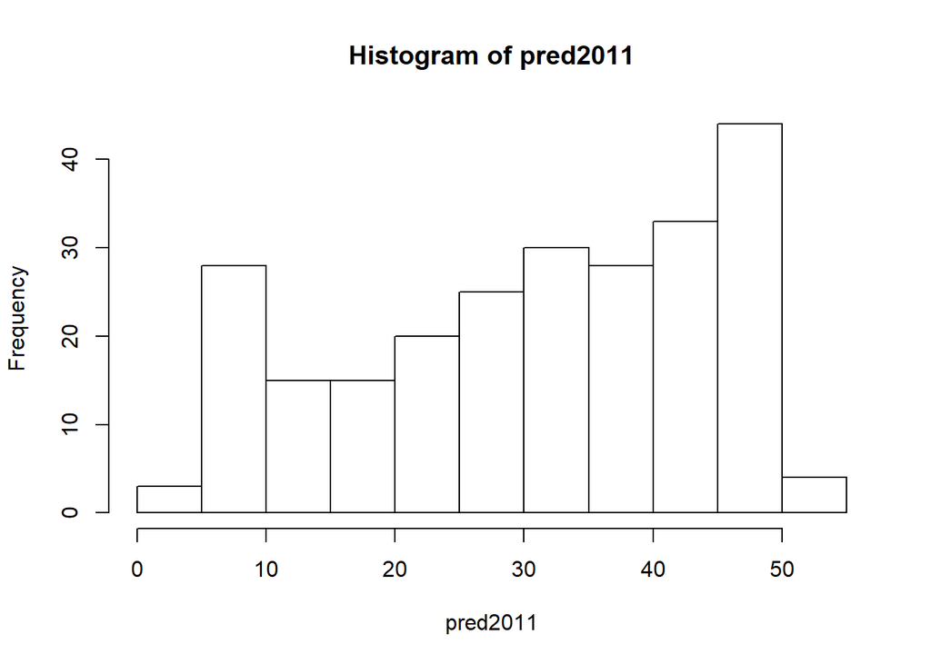

```r
pred2011 = predict(model2, cars2011)
#print(pred2011)
hist(pred2011)
```

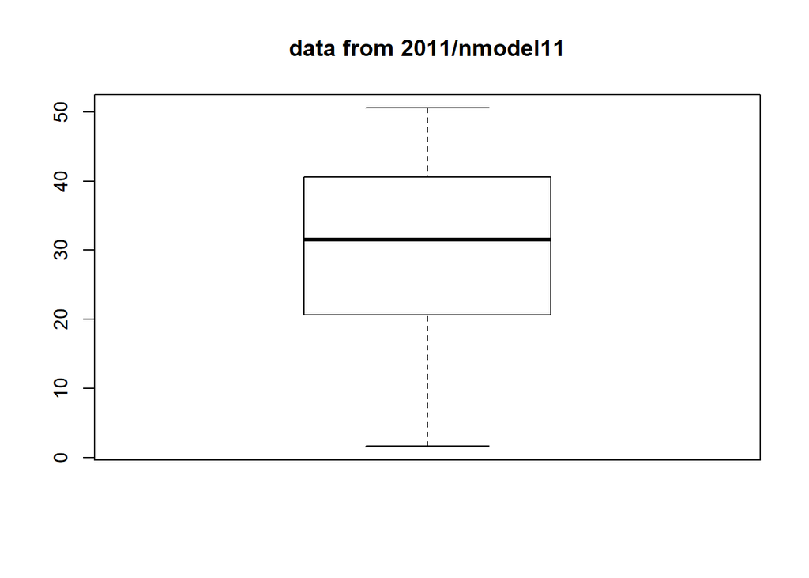

```r
boxplot(pred2011, main='data from 2011/nmodel11')
```

```r
t.test(cars2011a$FE, pred2011)
```

```
##
##  Welch Two Sample t-test
##
## data:  cars2011a$FE and pred2011
## t = 4.2827, df = 433.65, p-value = 2.276e-05
## alternative hypothesis: true difference in means is not equal to 0
## 95 percent confidence interval:
##  2.398171 6.466366
## sample estimates:
## mean of x mean of y
##  34.73066  30.29840
```

## Include other values in ANOVa